# Stage 4 - Mandalika new data

# Feature Encoding

```python
cats_updated = ['PreferredLoginDevice', 'PreferredPaymentMode', 'Gender', 'PreferedOrderCat', 'MaritalStatus']

for col in cats_updated:
  print(f'value counts of column {col}')
  print(df[col].value_counts())
  print('---'*10, '\n')
```

```
value counts of column PreferredLoginDevice
Mobile Phone    2417
Computer        1537
Phone           1230
Name: PreferredLoginDevice, dtype: int64
------------------------------

value counts of column PreferredPaymentMode
Debit Card          2129
Credit Card         1338
E wallet             570
UPI                  376
COD                  365
CC                   273
Cash on Delivery     133
Name: PreferredPaymentMode, dtype: int64
------------------------------

value counts of column Gender
Male      3104
Female    2080
Name: Gender, dtype: int64
------------------------------

value counts of column PreferedOrderCat
Laptop & Accessory    2042
Mobile Phone          1266
Fashion                823
Mobile                 808
Grocery                245
Name: PreferedOrderCat, dtype: int64
------------------------------

value counts of column MaritalStatus
Married     2725
Single      1697
Divorced     762
Name: MaritalStatus, dtype: int64
------------------------------
```

Data tidak sesuai (Mobile Phone = Phone, Credit Card = CC, dan COD = Cash on Delivery, Mobile Phone=Mobile) akan di rename

```python
df['PreferredLoginDevice'].replace(['Phone'], 'Mobile Phone', inplace=True)
df['PreferredPaymentMode'].replace(['CC'], 'Credit Card', inplace=True)
df['PreferredPaymentMode'].replace(['Cash on Delivery'], 'COD', inplace=True)
df['PreferedOrderCat'].replace(['Mobile'], 'Mobile Phone', inplace=True)
```

```python
#cek ulang setelah rename
cats_updated = ['PreferredLoginDevice', 'PreferredPaymentMode', 'Gender', 'PreferedOrderCat', 'MaritalStatus']

for col in cats_updated:
  print(f'value counts of column {col}')
  print(df[col].value_counts())
  print('---'*10, '\n')
```

```
value counts of column PreferredLoginDevice
Mobile Phone    3647
Computer        1537
Name: PreferredLoginDevice, dtype: int64
------------------------------

value counts of column PreferredPaymentMode
Debit Card     2129
Credit Card    1611
E wallet        570
COD             498
UPI             376
Name: PreferredPaymentMode, dtype: int64
------------------------------

value counts of column Gender
Male      3104
Female    2080
Name: Gender, dtype: int64
------------------------------

value counts of column PreferedOrderCat
Mobile Phone          2074
Laptop & Accessory    2042
Fashion                823
Grocery                245
Name: PreferedOrderCat, dtype: int64
------------------------------

value counts of column MaritalStatus
Married     2725
Single      1697
Divorced     762
Name: MaritalStatus, dtype: int64
------------------------------
```

Strategi encoding

```python
mapping_LoginDevice = {
    'Mobile Phone' : 0,
    'Computer' : 1
}

mapping_MaritalStatus = {
    'Married' : 0,
    'Single' : 1,
    'Divorced' : 2
}

mapping_Gender = {
    'Male' : 0,
    'Female' : 1
}

df['PreferredLoginDevice'] = df['PreferredLoginDevice'].map(mapping_LoginDevice)
#df['MaritalStatus'] = df['MaritalStatus'].map(mapping_MaritalStatus)
df['Gender'] = df['Gender'].map(mapping_Gender)
```

```python
for cat in ['PreferredPaymentMode', 'PreferedOrderCat', 'MaritalStatus']:
    onehots = pd.get_dummies(df[cat], prefix=cat)
    df = df.join(onehots)
```

```python
df.head()
```

|  | CustomerID | Churn | Tenure | PreferredLoginDevice | CityTier | WarehouseToHome | PreferredPaymentMode | Gender | HourSpendOnApp | NumberOfDeviceRegistered | ... | PreferredPaymentMode_Debit Card | PreferredPaymentMode_E wallet | PreferredPaymentMode_UPI | PreferedOrderCat_Fashion | PreferedOrderCat_Grocery | PreferedOrderCat_Laptop & Accessory | PreferedOrderCat_Mobile Phone | MaritalStatus_Divorced | MaritalStatus_Married | MaritalStatus_Single |
| --- | --- | --- | --- | --- | --- | --- | --- | --- | --- | --- | --- | --- | --- | --- | --- | --- | --- | --- | --- | --- | --- |
| 0 | 50001 | 1 | 1.504077 | 0 | 3 | 1.791759 | Debit Card | 1 | 0.093630 | -0.659697 | ... | 1 | 0 | 0 | 0 | 0 | 1 | 0 | 0 | 0 | 1 |
| 1 | 50002 | 1 | 2.251292 | 0 | 1 | 2.079442 | UPI | 0 | 0.093630 | 0.309654 | ... | 0 | 0 | 1 | 0 | 0 | 0 | 1 | 0 | 0 | 1 |
| 2 | 50003 | 1 | 2.251292 | 0 | 1 | 3.401197 | Debit Card | 0 | -1.333947 | 0.309654 | ... | 1 | 0 | 0 | 0 | 0 | 0 | 1 | 0 | 0 | 1 |
| 3 | 50004 | 1 | -0.693147 | 0 | 3 | 2.708050 | Debit Card | 0 | -1.333947 | 0.309654 | ... | 1 | 0 | 0 | 0 | 0 | 1 | 0 | 0 | 0 | 1 |
| 4 | 50005 | 1 | -0.693147 | 0 | 1 | 2.484907 | Credit Card | 0 | 0.093630 | -0.659697 | ... | 0 | 0 | 0 | 0 | 0 | 0 | 1 | 0 | 0 | 1 |

5 rows × 33 columns

```python
df.info()
```

```
<class 'pandas.core.frame.DataFrame'>
Int64Index: 5184 entries, 0 to 5629
Data columns (total 33 columns):
 #   Column                               Non-Null Count  Dtype
---  ------                               --------------  -----
 0   CustomerID                           5184 non-null   int64
 1   Churn                                5184 non-null   int64
 2   Tenure                               5184 non-null   float64
 3   PreferredLoginDevice                 5184 non-null   int64
 4   CityTier                             5184 non-null   int64
 5   WarehouseToHome                      5184 non-null   float64
 6   PreferredPaymentMode                 5184 non-null   object
 7   Gender                               5184 non-null   int64
 8   HourSpendOnApp                       5184 non-null   float64
 9   NumberOfDeviceRegistered             5184 non-null   float64
```

[output cut: 25 more lines]

# Feature Selection

```python
# drop kolom yang yang tidak relevan
df = df.drop(columns=['CustomerID','PreferredLoginDevice', 'PreferedOrderCat', 'PreferredPaymentMode', 'MaritalStatus'])
```

```python
df.info()
```

```
<class 'pandas.core.frame.DataFrame'>
Int64Index: 5184 entries, 0 to 5629
Data columns (total 28 columns):
 #   Column                               Non-Null Count  Dtype
---  ------                               --------------  -----
 0   Churn                                5184 non-null   int64
 1   Tenure                               5184 non-null   float64
 2   CityTier                             5184 non-null   int64
 3   WarehouseToHome                      5184 non-null   float64
 4   Gender                               5184 non-null   int64
 5   HourSpendOnApp                       5184 non-null   float64
 6   NumberOfDeviceRegistered             5184 non-null   float64
 7   SatisfactionScore                    5184 non-null   float64
 8   NumberOfAddress                      5184 non-null   float64
 9   Complain                             5184 non-null   int64
```

[output cut: 20 more lines]

# Feature Extraction

```python
df['OtherRevenue']= df['CashbackAmount']/0.05
df.info()
```

```
<class 'pandas.core.frame.DataFrame'>
Int64Index: 5184 entries, 0 to 5629
Data columns (total 29 columns):
 #   Column                               Non-Null Count  Dtype
---  ------                               --------------  -----
 0   Churn                                5184 non-null   int64
 1   Tenure                               5184 non-null   float64
 2   CityTier                             5184 non-null   int64
 3   WarehouseToHome                      5184 non-null   float64
 4   Gender                               5184 non-null   int64
 5   HourSpendOnApp                       5184 non-null   float64
 6   NumberOfDeviceRegistered             5184 non-null   float64
 7   SatisfactionScore                    5184 non-null   float64
 8   NumberOfAddress                      5184 non-null   float64
 9   Complain                             5184 non-null   int64
```

[output cut: 21 more lines]

```python
df.duplicated().sum()
```

```
520
```

```python
print(f'Jumlah row duplicated sebelum dihapus {df.duplicated().sum()}')
df.drop_duplicates(inplace=True) # note: default-nya keep='First' (tidak perlu ditulis)
print(f'Jumlah row duplicated SETELAH dihapus {df.duplicated().sum()}')
```

```
Jumlah row duplicated sebelum dihapus 520
Jumlah row duplicated SETELAH dihapus 0
```

```python
df.info()
```

```
<class 'pandas.core.frame.DataFrame'>
Int64Index: 4664 entries, 0 to 5629
Data columns (total 29 columns):
 #   Column                               Non-Null Count  Dtype
---  ------                               --------------  -----
 0   Churn                                4664 non-null   int64
 1   Tenure                               4664 non-null   float64
 2   CityTier                             4664 non-null   int64
 3   WarehouseToHome                      4664 non-null   float64
 4   Gender                               4664 non-null   int64
 5   HourSpendOnApp                       4664 non-null   float64
 6   NumberOfDeviceRegistered             4664 non-null   float64
 7   SatisfactionScore                    4664 non-null   float64
 8   NumberOfAddress                      4664 non-null   float64
 9   Complain                             4664 non-null   int64
```

[output cut: 21 more lines]

```python
# drop kolom yang yang tidak relevan
df = df.drop(columns=['OtherRevenue', 'CashbackAmount'])
```

# Split Data

```python
X = df[['Tenure', 'CityTier', 'Gender','WarehouseToHome','NumberOfDeviceRegistered','SatisfactionScore', 'Complain','DaySinceLastOrder','CashbackAmount_std',
        'HourSpendOnApp', 'NumberOfAddress', 'OrderAmountHikeFromlastYear','CouponUsed','OrderCount', 'PreferredPaymentMode_COD','PreferredPaymentMode_Credit Card',
        'MaritalStatus_Divorced', 'MaritalStatus_Married', 'MaritalStatus_Single', 'PreferredPaymentMode_Debit Card','PreferredPaymentMode_E wallet','PreferredPaymentMode_UPI',
        'PreferedOrderCat_Fashion','PreferedOrderCat_Grocery', 'PreferedOrderCat_Laptop & Accessory','PreferedOrderCat_Mobile Phone']]
y = df[['Churn']]

#Splitting the data into Train and Test
from sklearn.model_selection import train_test_split
Xtr, Xtest, ytr, ytest = train_test_split(X,y, stratify=y, test_size=0.2, random_state=123)
```

```python
ytest[ytest['Churn']==1].count()
```

```
Churn    164
dtype: int64
```

```python
ytest[ytest['Churn']==0].count()
```

```
Churn    769
dtype: int64
```

```python
Xtr.info()
```

```
<class 'pandas.core.frame.DataFrame'>
Int64Index: 3731 entries, 696 to 5086
Data columns (total 26 columns):
 #   Column                               Non-Null Count  Dtype
---  ------                               --------------  -----
 0   Tenure                               3731 non-null   float64
 1   CityTier                             3731 non-null   int64
 2   Gender                               3731 non-null   int64
 3   WarehouseToHome                      3731 non-null   float64
 4   NumberOfDeviceRegistered             3731 non-null   float64
 5   SatisfactionScore                    3731 non-null   float64
 6   Complain                             3731 non-null   int64
 7   DaySinceLastOrder                    3731 non-null   float64
 8   CashbackAmount_std                   3731 non-null   float64
 9   HourSpendOnApp                       3731 non-null   float64
```

[output cut: 18 more lines]

# Imbalanced Dataset

```python
# pembuatan binary label target
ytr['Churn_class'] = ytr['Churn'] >=1
ytr['Churn_class'].value_counts()
```

```
False    3073
True      658
Name: Churn_class, dtype: int64
```

```python
# pemisahan features vs target
X = Xtr[[col for col in Xtr.columns if (str(Xtr[col].dtype) != 'object') and col not in ['Churn', 'Churn_class']]]
y = ytr['Churn_class'].values
print(X.shape)
print(y.shape)
```

```
(3731, 26)
(3731,)
```

```python
!pip install imblearn
```

```python
from imblearn import under_sampling, over_sampling
X_under, y_under = under_sampling.RandomUnderSampler(1).fit_resample(X, y)
X_over, y_over = over_sampling.RandomOverSampler(1).fit_resample(X, y)
X_over_SMOTE, y_over_SMOTE = over_sampling.SMOTE(1).fit_resample(X, y)
```

```python
print('Original')
print(pd.Series(y).value_counts())
print('\n')
print('UNDERSAMPLING')
print(pd.Series(y_under).value_counts())
print('\n')
print('OVERSAMPLING')
print(pd.Series(y_over).value_counts())
print('\n')
print('SMOTE')
print(pd.Series(y_over_SMOTE).value_counts())
```

```
Original
False    3073
True      658
dtype: int64


UNDERSAMPLING
True     658
False    658
dtype: int64


OVERSAMPLING
True     3073
False    3073
dtype: int64


SMOTE
True     3073
False    3073
dtype: int64
```

Dataset yang akan digunakan berdasarkan SMOTE

```python
Xtrain=X_over_SMOTE.copy()
ytrain=y_over_SMOTE.copy()
```

```python
Xtrain.info()
```

```
<class 'pandas.core.frame.DataFrame'>
RangeIndex: 6146 entries, 0 to 6145
Data columns (total 26 columns):
 #   Column                               Non-Null Count  Dtype
---  ------                               --------------  -----
 0   Tenure                               6146 non-null   float64
 1   CityTier                             6146 non-null   int64
 2   Gender                               6146 non-null   int64
 3   WarehouseToHome                      6146 non-null   float64
 4   NumberOfDeviceRegistered             6146 non-null   float64
 5   SatisfactionScore                    6146 non-null   float64
 6   Complain                             6146 non-null   int64
 7   DaySinceLastOrder                    6146 non-null   float64
 8   CashbackAmount_std                   6146 non-null   float64
 9   HourSpendOnApp                       6146 non-null   float64
```

[output cut: 18 more lines]

# distribusi nilai asli

```python
Xtrain.shape
```

```
(6146, 26)
```

```python
ytrain.shape
```

```
(6146,)
```

```python
Xtest.shape
```

```
(933, 26)
```

```python
ytest.shape
```

```
(933, 1)
```

# kNN

```python
from sklearn.metrics import accuracy_score, precision_score, recall_score, f1_score, roc_auc_score, confusion_matrix
import matplotlib.pyplot as plt

def eval_classification(model):
    y_pred = model.predict(Xtest)
    y_pred_train = model.predict(Xtrain)
    y_pred_proba = model.predict_proba(Xtest)
    y_pred_proba_train = model.predict_proba(Xtrain)

    print("Accuracy (Test Set): %.2f" % accuracy_score(ytest, y_pred))
    print("Accuracy (Train Set): %.2f" % accuracy_score(ytrain, y_pred_train))

    print("Precision (Test Set): %.2f" % precision_score(ytest, y_pred))
    print("Precision (Train Set): %.2f" % precision_score(ytrain, y_pred_train))

    print("Recall (Test Set): %.2f" % recall_score(ytest, y_pred))
    print("Recall (Train Set): %.2f" % recall_score(ytrain, y_pred_train))

    print("F1-Score (Test Set): %.2f" % f1_score(ytest, y_pred))
    print("F1-Score (Train Set): %.2f" % f1_score(ytrain, y_pred_train))

    print("AUC (test-proba): %.2f" % roc_auc_score(ytest, y_pred_proba[:, 1]))
    print("AUC (train-proba): %.2f" % roc_auc_score(ytrain, y_pred_proba_train[:, 1]))

    print(confusion_matrix(ytest, y_pred))
#     print("AUC (test-label): %.2f" % roc_auc_score(ytest, y_pred))
#     print("AUC (train-label): %.2f" % roc_auc_score(ytrain, y_pred_train))

def show_feature_importance(model):
    feat_importances = pd.Series(model.feature_importances_, index=X.columns)
    ax = feat_importances.nlargest(25).plot(kind='barh', figsize=(10, 8))
    ax.invert_yaxis()

    plt.xlabel('score')
    plt.ylabel('feature')
    plt.title('feature importance score')

def show_best_hyperparameter(model):
    print(model.best_estimator_.get_params())
```

```python
from sklearn.neighbors import KNeighborsClassifier
neigh = KNeighborsClassifier()
neigh.fit(Xtrain, ytrain)

y_pred = neigh.predict(Xtest)
eval_classification(neigh)
```

```
Accuracy (Test Set): 0.88
Accuracy (Train Set): 0.95
Precision (Test Set): 0.61
Precision (Train Set): 0.92
Recall (Test Set): 0.90
Recall (Train Set): 1.00
F1-Score (Test Set): 0.73
F1-Score (Train Set): 0.96
AUC (test-proba): 0.95
AUC (train-proba): 1.00
[[674  95]
 [ 16 148]]
```

## Hyperparameter Tuning with RandomSearch

```python
from sklearn.model_selection import RandomizedSearchCV
from scipy.stats import uniform
from sklearn.neighbors import KNeighborsClassifier

# List of hyperparameter
leaf_size = list(range(1,50))
n_neighbors = list(range(1,30))
p=[1,2]
algorithm = ['auto', 'ball_tree', 'kd_tree', 'brute']
hyperparameters = dict(n_neighbors=n_neighbors, p=p, algorithm=algorithm)

# Init model
knn = KNeighborsClassifier()
modelknn = RandomizedSearchCV(knn, hyperparameters, cv=5, random_state=123, scoring='recall')

# Fit Model & Evaluasi
modelknn.fit(Xtrain, ytrain)
y_pred = modelknn.predict(Xtest)
eval_classification(modelknn)
```

```
Accuracy (Test Set): 0.87
Accuracy (Train Set): 0.93
Precision (Test Set): 0.58
Precision (Train Set): 0.88
Recall (Test Set): 0.93
Recall (Train Set): 1.00
F1-Score (Test Set): 0.71
F1-Score (Train Set): 0.93
AUC (test-proba): 0.95
AUC (train-proba): 1.00
[[657 112]
 [ 12 152]]
```

```python
print('Best leaf_size:', modelknn.best_estimator_.get_params()['leaf_size'])
print('Best n_neighbors:', modelknn.best_estimator_.get_params()['n_neighbors'])
print('Best p:', modelknn.best_estimator_.get_params()['p'])
print('Best algorithm:', modelknn.best_estimator_.get_params()['algorithm'])
```

```
Best leaf_size: 30
Best n_neighbors: 9
Best p: 1
Best algorithm: brute
```

```python
modelknn.best_estimator_.get_params()
```

```
{'algorithm': 'brute',
 'leaf_size': 30,
 'metric': 'minkowski',
 'metric_params': None,
 'n_jobs': None,
 'n_neighbors': 9,
 'p': 1,
 'weights': 'uniform'}
```

# Logistic Regression

```python
from sklearn.linear_model import LogisticRegression
lr = LogisticRegression(random_state=123)
lr.fit(Xtrain, ytrain)
eval_classification(lr)
```

```
Accuracy (Test Set): 0.86
Accuracy (Train Set): 0.87
Precision (Test Set): 0.58
Precision (Train Set): 0.88
Recall (Test Set): 0.70
Recall (Train Set): 0.86
F1-Score (Test Set): 0.64
F1-Score (Train Set): 0.87
AUC (test-proba): 0.88
AUC (train-proba): 0.95
[[688  81]
 [ 50 114]]
```

```python
# tune hyperparam
from sklearn.model_selection import RandomizedSearchCV, GridSearchCV

penalty = ['l1', 'l2']
C = [float(x) for x in np.linspace(0.01, 1, num = 30)]
solver = ['newton-cg', 'sag', 'saga', 'lbfgs']
hyperparams = dict(penalty=penalty, C=C, solver=solver)

lr = LogisticRegression(random_state=123)
gs = RandomizedSearchCV(lr, hyperparams, cv=5, scoring='recall')
gs.fit(Xtrain, ytrain)
eval_classification(gs)
```

```
Accuracy (Test Set): 0.86
Accuracy (Train Set): 0.87
Precision (Test Set): 0.58
Precision (Train Set): 0.88
Recall (Test Set): 0.70
Recall (Train Set): 0.86
F1-Score (Test Set): 0.64
F1-Score (Train Set): 0.87
AUC (test-proba): 0.88
AUC (train-proba): 0.95
[[688  81]
 [ 50 114]]
```

# Decision Tree

```python
from sklearn.tree import DecisionTreeClassifier
model = DecisionTreeClassifier(random_state=123)
model.fit(Xtrain, ytrain)

y_pred = model.predict(Xtest)
eval_classification(model)
```

```
Accuracy (Test Set): 0.92
Accuracy (Train Set): 1.00
Precision (Test Set): 0.76
Precision (Train Set): 1.00
Recall (Test Set): 0.82
Recall (Train Set): 1.00
F1-Score (Test Set): 0.79
F1-Score (Train Set): 1.00
AUC (test-proba): 0.88
AUC (train-proba): 1.00
[[727  42]
 [ 30 134]]
```

```python
from sklearn.model_selection import RandomizedSearchCV
from scipy.stats import uniform
import numpy as np

# List of hyperparameter
max_depth = [int(x) for x in np.linspace(1, 150, num = 30)]
min_samples_split = [10, 100]
min_samples_leaf = [2, 4, 10]
max_features = ['auto', 'sqrt']
ccp_alpha =[0.0]

hyperparameters = dict(max_depth=max_depth,
                       min_samples_split=min_samples_split,
                       min_samples_leaf=min_samples_leaf,
                       max_features=max_features,
                       ccp_alpha=ccp_alpha
                      )

# Inisialisasi Model
dt = DecisionTreeClassifier(random_state=123)
dt = RandomizedSearchCV(dt, hyperparameters, cv=5, random_state=123, scoring='recall')
dt.fit(Xtrain, ytrain)
# Predict & Evaluation
y_pred = dt.predict(Xtest)
eval_classification(dt)
```

```
Accuracy (Test Set): 0.88
Accuracy (Train Set): 0.96
Precision (Test Set): 0.65
Precision (Train Set): 0.96
Recall (Test Set): 0.66
Recall (Train Set): 0.95
F1-Score (Test Set): 0.66
F1-Score (Train Set): 0.96
AUC (test-proba): 0.88
AUC (train-proba): 0.99
[[710  59]
 [ 55 109]]
```

# Random Forest

```python
from sklearn.ensemble import RandomForestClassifier
rf = RandomForestClassifier(random_state=123)
rf.fit(Xtrain,ytrain)
eval_classification(rf)
```

```
Accuracy (Test Set): 0.94
Accuracy (Train Set): 1.00
Precision (Test Set): 0.88
Precision (Train Set): 1.00
Recall (Test Set): 0.79
Recall (Train Set): 1.00
F1-Score (Test Set): 0.83
F1-Score (Train Set): 1.00
AUC (test-proba): 0.98
AUC (train-proba): 1.00
[[751  18]
 [ 35 129]]
```

**Hyperparameter yang biasa di tuning pada Random Forest:** ([Dokumentasi Sklearn Random Forest](https://scikit-learn.org/stable/modules/generated/sklearn.ensemble.RandomForestClassifier.html))

- n_estimators: jumlah subtree yang akan dibangun
- max_samples: Jumlah maksimal sampel pada masing-masing training subset (setelah proses bootstrap)

Sisa hyperparameter lainnya sama dengan Decision Tree, yaitu:

- criterion: cara menghitung impurity pada feature (gini, entropy). melihat feature mana yang menjadi root/node
- max_depth: maksimal kedalaman tree untuk mencegah overfitting
- min_sample_split: berapa jumlah sample yg dibutuhkan pada node untuk membuat leaf baru (agar tidak terlalu sedikit sehingga mengakibatkan overfit)
- min_sample_leaf: berapa jumlah sample yg dibutuhkan pada leaf agar leaf terbentuk (agar tidak terlalu sedikit sehingga mengakibatkan overfit)
- ccp_alpha: jika cost/error dari sebuah leaf/subtree lebih besar daripada ccp_alpha, subtree tersebut akan kita hapus/prune sehingga meminimalisir error/variance dari model

```python
from sklearn.model_selection import RandomizedSearchCV, GridSearchCV

import numpy as np

#List Hyperparameters yang akan diuji
hyperparameters = dict(
                       n_estimators = [int(x) for x in np.linspace(start = 1, stop = 100, num = 100)], # Jumlah subtree
                       bootstrap = [True], # Apakah pakai bootstrapping atau tidak
                       criterion = ['gini','entropy'],
                       max_depth = [int(x) for x in np.linspace(10, 110, num = 11)],  # Maximum kedalaman tree
                       min_samples_split = [int(x) for x in np.linspace(start = 2, stop = 10, num = 5)], # Jumlah minimum samples pada node agar boleh di split menjadi leaf baru
                       min_samples_leaf = [int(x) for x in np.linspace(start = 1, stop = 10, num = 5)], # Jumlah minimum samples pada leaf agar boleh terbentuk leaf baru
                       max_features = ['auto', 'sqrt', 'log2'], # Jumlah feature yg dipertimbangkan pada masing-masing split
                       n_jobs = [-1], # Core untuk parallel computation. -1 untuk menggunakan semua core
                      )

# Init
rf = RandomForestClassifier(random_state=123)
rf_tuned = RandomizedSearchCV(rf, hyperparameters, cv=5, scoring='recall')
rf_tuned.fit(Xtrain, ytrain)

# Predict & Evaluation
eval_classification(rf_tuned)
```

```
Accuracy (Test Set): 0.94
Accuracy (Train Set): 1.00
Precision (Test Set): 0.89
Precision (Train Set): 1.00
Recall (Test Set): 0.77
Recall (Train Set): 1.00
F1-Score (Test Set): 0.83
F1-Score (Train Set): 1.00
AUC (test-proba): 0.98
AUC (train-proba): 1.00
[[753  16]
 [ 37 127]]
```

```python
rf_tuned.best_estimator_.get_params()
```

```
{'bootstrap': True,
 'ccp_alpha': 0.0,
 'class_weight': None,
 'criterion': 'gini',
 'max_depth': 50,
 'max_features': 'auto',
 'max_leaf_nodes': None,
 'max_samples': None,
 'min_impurity_decrease': 0.0,
 'min_samples_leaf': 1,
 'min_samples_split': 4,
 'min_weight_fraction_leaf': 0.0,
 'n_estimators': 23,
 'n_jobs': -1,
 'oob_score': False,
 'random_state': 123,
 'verbose': 0,
 'warm_start': False}
```

# XGBoost

```python
from xgboost import XGBClassifier
xg = XGBClassifier(random_state=123)
xg.fit(Xtrain, ytrain)

y_pred = xg.predict(Xtest)
eval_classification(xg)
```

```
[21:25:48] WARNING: C:/Users/Administrator/workspace/xgboost-win64_release_1.5.1/src/learner.cc:1115: Starting in XGBoost 1.3.0, the default evaluation metric used with the objective 'binary:logistic' was changed from 'error' to 'logloss'. Explicitly set eval_metric if you'd like to restore the old …
Accuracy (Test Set): 0.95
Accuracy (Train Set): 1.00
Precision (Test Set): 0.90
Precision (Train Set): 1.00
Recall (Test Set): 0.84
Recall (Train Set): 1.00
F1-Score (Test Set): 0.87
F1-Score (Train Set): 1.00
AUC (test-proba): 0.99
AUC (train-proba): 1.00
[[754  15]
 [ 27 137]]
```

```
[20:42:00] WARNING: C:/Users/Administrator/workspace/xgboost-win64_release_1.5.1/src/learner.cc:1115: Starting in XGBoost 1.3.0, the default evaluation metric used with the objective 'binary:logistic' was changed from 'error' to 'logloss'. Explicitly set eval_metric if you'd like to restore the old …
```

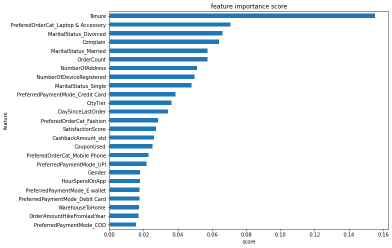

```python
from xgboost import XGBClassifier
xg = XGBClassifier(random_state=123)
xg.fit(Xtrain, ytrain)
y_pred = xg.predict(Xtest)
# plt.figsize(10, 8)
feat_importances = pd.Series(xg.feature_importances_, index=X.columns)
ax = feat_importances.nlargest(25).plot(kind='barh', figsize=(10, 8))
ax.invert_yaxis()

plt.xlabel('score')
plt.ylabel('feature')
plt.title('feature importance score')
```

```python
from sklearn.model_selection import RandomizedSearchCV, GridSearchCV
import numpy as np

#Menjadikan ke dalam bentuk dictionary
hyperparameters = { #'n_estimators' : [31],
                    'max_depth' : [int(x) for x in np.linspace(10, 110, num = 11)],
                    #'max_depth' : [int(x) for x in np.linspace(10, 30, num = 20)]
                   #'min_child_weight' : [int(x) for x in np.linspace(1, 20, num = 11)],
                   #'gamma' : [float(x) for x in np.linspace(0, 1, num = 11)],
                   #'tree_method' : ['auto', 'exact', 'approx', 'hist'],
                   #'colsample_bytree' : [float(x) for x in np.linspace(0, 1, num = 11)],
                   #'eta' : [float(x) for x in np.linspace(0, 1, num = 11)],
                   #'subsample' : [float(x) for x in np.linspace(0, 1, num = 11)],
                  'lambda' : [float(x) for x in np.linspace(0, 1, num = 11)],
                   'alpha' : [float(x) for x in np.linspace(0, 1, num = 11)]
                  }

# Init
xg = XGBClassifier(random_state=123)
xg_tuned = RandomizedSearchCV(xg, hyperparameters, cv=5, random_state=123, scoring='recall')
xg_tuned.fit(Xtrain,ytrain)

# Predict & Evaluation
eval_classification(xg_tuned)
```

[output not shown]

[output cut: 46 more lines]

```python
xg_tuned.best_estimator_.get_params()
```

[output not shown]

# Learning Curve

[output not shown]

[output cut: 174 more lines]

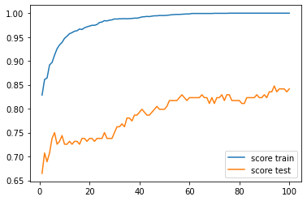

```python
import numpy as np
values = [int(x) for x in np.linspace(1, 100, num=100)]

train_score = []
test_score = []

from sklearn.metrics import recall_score
from xgboost import XGBClassifier
for x in values:

    #init
    xgb = XGBClassifier(n_estimators=x)
    xgb.fit(Xtrain,ytrain)

    # eval test
    y_pred = xgb.predict(Xtest)
    recall_test = recall_score(ytest, y_pred)
    test_score.append(recall_test)

    # eval train
    y_pred_train = xgb.predict(Xtrain)
    recall_train = recall_score(ytrain, y_pred_train)
    train_score.append(recall_train)

    print('n_estimators: '+ str(x) + '; recall(train): '+ str(recall_train) + '; recall(test): ' + str(recall_test))

from matplotlib import pyplot as plt
plt.plot(values, train_score, label='score train')
plt.plot(values, test_score, label='score test')
plt.legend()
plt.show()
```

```python
from sklearn.model_selection import RandomizedSearchCV, GridSearchCV
import numpy as np

#Menjadikan ke dalam bentuk dictionary
hyperparameters = {
                 'max_depth' : [int(x) for x in np.linspace(10, 30, num = 20)],
                 'lambda' : [float(x) for x in np.linspace(0, 1, num = 50)],
                }

# Init
xg = XGBClassifier(random_state=123, n_estimator=2)
xg_tuned = RandomizedSearchCV(xg, hyperparameters, cv=5, random_state=123, scoring='recall')
xg_tuned.fit(Xtrain,ytrain)

# Predict & Evaluation
eval_classification(xg_tuned)
```

[output not shown]

[output cut: 365 more lines]

```
  but getting flagged wrongly here. Please open an issue if you find any such cases.


Accuracy (Test Set): 0.95
Accuracy (Train Set): 1.00
Precision (Test Set): 0.90
Precision (Train Set): 1.00
Recall (Test Set): 0.84
Recall (Train Set): 1.00
F1-Score (Test Set): 0.87
F1-Score (Train Set): 1.00
AUC (test-proba): 0.99
AUC (train-proba): 1.00
[[753  16]
 [ 26 138]]
```

```python
import numpy as np
values = [int(x) for x in np.linspace(1, 200, num=50)]

train_score = []
test_score = []

hyperparameters = {'max_depth' : [int(x) for x in np.linspace(10, 20, num = 30)],
                   #'min_child_weight' : [int(x) for x in np.linspace(1, 20, num = 11)],
                   #'gamma' : [float(x) for x in np.linspace(0, 1, num = 11)],
                   #'tree_method' : ['auto', 'exact', 'approx', 'hist'],
                   #'colsample_bytree' : [float(x) for x in np.linspace(0, 1, num = 11)],
                   #'eta' : [float(x) for x in np.linspace(0, 1, num = 11)],
                   #'subsample' : [float(x) for x in np.linspace(0, 1, num = 11)],
                   'lambda' : [float(x) for x in np.linspace(0, 1, num = 50)]
                   #'alpha' : [float(x) for x in np.linspace(0, 1, num = 11)]
                  }

from sklearn.metrics import recall_score
from xgboost import XGBClassifier
for x in values:

    #init
    xgb = XGBClassifier(n_estimators=x)
    xg_tuned = RandomizedSearchCV(xg, hyperparameters, cv=5, random_state=123, scoring='recall')
    xg_tuned.fit(Xtrain,ytrain)

    # eval test
    y_pred = xg_tuned.predict(Xtest)
    recall_test = recall_score(ytest, y_pred)
    test_score.append(recall_test)

    # eval train
    y_pred_train = xg_tuned.predict(Xtrain)
    recall_train = recall_score(ytrain, y_pred_train)
    train_score.append(recall_train)

    print('n_estimators: '+ str(x) + '; recall(train): '+ str(recall_train) + '; recall(test): ' + str(recall_test))

from matplotlib import pyplot as plt
plt.plot(values, train_score, label='score train')
plt.plot(values, test_score, label='score test')
plt.legend()
plt.show()
```

[output not shown]

[output cut: 624 more lines]

[output not shown]

[output not shown]

[output cut: 74 more lines]

[output not shown]

```python
import numpy as np
values = [int(x) for x in np.linspace(1, 100, num=100)]

train_score = []
test_score = []

#Menjadikan ke dalam bentuk dictionary
hyperparameters = {'max_depth' : [int(x) for x in np.linspace(10, 200, num = 20)],
                   #'min_child_weight' : [int(x) for x in np.linspace(1, 20, num = 11)],
                   #'gamma' : [float(x) for x in np.linspace(0, 1, num = 11)],
                   #'tree_method' : ['auto', 'exact', 'approx', 'hist'],
                   #'colsample_bytree' : [float(x) for x in np.linspace(0, 1, num = 11)],
                   'eta' : [float(x) for x in np.linspace(0, 1, num = 11)],
                   'subsample' : [float(x) for x in np.linspace(0, 1, num = 11)],
                   'lambda' : [float(x) for x in np.linspace(0, 1, num = 11)]
                   #'alpha' : [float(x) for x in np.linspace(0, 1, num = 11)]
                  }

from sklearn.model_selection import RandomizedSearchCV
from sklearn.metrics import recall_score
from xgboost import XGBClassifier
for x in values:
    model = XGBClassifier(n_estimators=x)
    xg_tuned = RandomizedSearchCV(model, hyperparameters, cv=5, random_state=123, scoring='recall')
    xg_tuned.fit(Xtrain, ytrain)

    # eval test
    y_pred = xg_tuned.predict(Xtest)
    recall_test = recall_score(ytest, y_pred)
    test_score.append(recall_test)

     # eval train
    y_pred_train = xg_tuned.predict(Xtrain)
    recall_train = recall_score(ytrain, y_pred_train)
    train_score.append(recall_train)

    print('n_estimators: '+ str(x) + '; recall(train): '+ str(recall_train) + '; recall(test): ' + str(recall_test))

from matplotlib import pyplot as plt
plt.plot(values, train_score, label='score train')
plt.plot(values, test_score, label='score test')
plt.legend()
plt.show()
```

[output not shown]

# Adaboost

```python
from sklearn.ensemble import AdaBoostClassifier
ab = AdaBoostClassifier(random_state=123)
ab.fit(Xtrain,ytrain)

eval_classification(ab)
```

[output not shown]

```python
from sklearn.model_selection import RandomizedSearchCV, GridSearchCV
import numpy as np

# List of hyperparameter
hyperparameters = dict(n_estimators = [int(x) for x in np.linspace(start = 50, stop = 500, num = 500)], # Jumlah iterasi
                       learning_rate = [float(x) for x in np.linspace(start = 0.001, stop = 0.1, num = 200)],
                       algorithm = ['SAMME', 'SAMME.R']
                      )

# Init model
ab = AdaBoostClassifier(random_state=123)
ab_tuned = RandomizedSearchCV(ab, hyperparameters, random_state=123, cv=5, scoring='recall')
ab_tuned.fit(Xtrain,ytrain)

# Predict & Evaluation
eval_classification(ab_tuned)
```

[output not shown]